# Quiz 4

## 1)

Load the vowel.train and vowel.test data sets.

Set the variable y to be a factor variable in both the training and test set. Then set the seed to 33833. Fit (1) a random forest predictor relating the factor variable y to the remaining variables and (2) a boosted predictor using the “gbm” method. Fit these both with the train() command in the caret package.

What are the accuracies for the two approaches on the test data set? What is the accuracy among the test set samples where the two methods agree?

```r
data(vowel.train)
data(vowel.test)

set.seed(33833)

vowel.train$y <- as.factor(vowel.train$y)
vowel.test$y <- as.factor(vowel.test$y)

modForest <- randomForest(y ~ ., data = vowel.train)
print(modForest)
```

```
Call:
 randomForest(formula = y ~ ., data = vowel.train)
               Type of random forest: classification
                     Number of trees: 500
No. of variables tried at each split: 3

        OOB estimate of  error rate: 3.22%
Confusion matrix:
    1  2  3  4  5  6  7  8  9 10 11 class.error
1  48  0  0  0  0  0  0  0  0  0  0  0.00000000
2   1 47  0  0  0  0  0  0  0  0  0  0.02083333
3   0  0 48  0  0  0  0  0  0  0  0  0.00000000
4   0  0  0 47  0  1  0  0  0  0  0  0.02083333
5   0  0  0  0 45  2  0  0  0  0  1  0.06250000
6   0  0  0  1  0 42  0  0  0  0  5  0.12500000
7   0  0  0  0  2  0 44  2  0  0  0  0.08333333
8   0  0  0  0  0  0  0 48  0  0  0  0.00000000
9   0  0  0  0  0  0  1  0 47  0  0  0.02083333
10  0  0  0  0  0  0  1  0  0 47  0  0.02083333
11  0  0  0  0  0  0  0  0  0  0 48  0.00000000
```

```r
modBoost <- train(y ~ ., method="gbm",data=vowel.train,verbose=FALSE)
print(modBoost)
```

```
Stochastic Gradient Boosting

528 samples
 10 predictor
 11 classes: '1', '2', '3', '4', '5', '6', '7', '8', '9', '10', '11'

No pre-processing
Resampling: Bootstrapped (25 reps)
Summary of sample sizes: 528, 528, 528, 528, 528, 528, ...
Resampling results across tuning parameters:

  interaction.depth  n.trees  Accuracy   Kappa
  1                   50      0.6936472  0.6628276
  1                  100      0.7586902  0.7342438
  1                  150      0.7880811  0.7665370
  2                   50      0.8105098  0.7912267
  2                  100      0.8496399  0.8342737
  2                  150      0.8604207  0.8461514
  3                   50      0.8424550  0.8263864
  3                  100      0.8708727  0.8576814
  3                  150      0.8795421  0.8672186

Tuning parameter 'shrinkage' was held constant at a value of 0.1
Tuning parameter
 'n.minobsinnode' was held constant at a value of 10
Accuracy was used to select the optimal model using the largest value.
The final values used for the model were n.trees = 150, interaction.depth = 3, shrinkage = 0.1
 and n.minobsinnode = 10.
```

```r
predictForest <- predict(modForest,vowel.test)
predictBoost <- predict(modBoost,vowel.test)

# Accuracy of each model
confusionMatrix(predictForest, vowel.test$y)$overall['Accuracy']
```

```
 Accuracy
0.5800866
```

```r
confusionMatrix(predictBoost, vowel.test$y)$overall['Accuracy']
```

```
Accuracy
0.517316
```

```r
# Accuracy for the 2 approaches on the test data set
confusionMatrix(predictForest, predictBoost)$overall
```

```
      Accuracy          Kappa  AccuracyLower  AccuracyUpper   AccuracyNull AccuracyPValue
  6.904762e-01   6.572594e-01   6.461165e-01   7.323769e-01   1.796537e-01  4.540394e-128
 McnemarPValue
           NaN
```

```r
# Accuracy among the test set samples where the two methods agree
agree_Forest_Boost <- (predictBoost == predictForest)
head(agree_Forest_Boost)
```

```
[1]  TRUE FALSE  TRUE  TRUE  TRUE  TRUE
```

```r
confusionMatrix(vowel.test$y[agree_Forest_Boost], predictBoost[agree_Forest_Boost])$overall['Accuracy']
```

```
 Accuracy
0.6238245
```

```r
confusionMatrix(vowel.test$y[agree_Forest_Boost], predictForest[agree_Forest_Boost])$overall['Accuracy']
```

```
 Accuracy
0.6238245
```

## 2)

Load the Alzheimer’s data.

Set the seed to 62433 and predict diagnosis with all the other variables using a random forest (“rf”), boosted trees (“gbm”) and linear discriminant analysis (“lda”) model. Stack the predictions together using random forests (“rf”). What is the resulting accuracy on the test set? Is it better or worse than each of the individual predictions?

```r
set.seed(3433)
data(AlzheimerDisease)
adData = data.frame(diagnosis,predictors)
inTrain = createDataPartition(adData$diagnosis, p = 3/4)[[1]]
training = adData[ inTrain,]
testing = adData[-inTrain,]

set.seed(62433)

# Random forest
modForest <- randomForest(diagnosis ~ ., data = training)

# Boosted trees
modBoost <- train(diagnosis ~ ., method="gbm",data=training,verbose=FALSE)

# Linear discriminant analysis
modLin <- train(diagnosis ~ ., method="lda",data=training,verbose=FALSE)

# test
predictForest <- predict(modForest,testing)
predictBoost <- predict(modBoost,testing)
predictLin <- predict(modLin,testing)

# Combine
predDF <- data.frame(predictForest, predictBoost, predictLin, diagnosis = testing$diagnosis)
combModFit <- train(diagnosis ~ ., method = "rf", data = predDF)
combPred <- predict(combModFit, predDF)

# Accuracies
confusionMatrix(predictForest, testing$diagnosis)$overall[1]
```

```
Accuracy
0.804878
```

```r
confusionMatrix(predictBoost, testing$diagnosis)$overall[1]
```

```
 Accuracy
0.7926829
```

```r
confusionMatrix(predictLin, testing$diagnosis)$overall[1]
```

```
 Accuracy
0.7682927
```

```r
confusionMatrix(combPred, testing$diagnosis)$overall[1]
```

```
 Accuracy
0.8170732
```

## 3)

Load the concrete data.

Set the seed to 233 and fit a lasso model to predict Compressive Strength. Which variable is the last coefficient to be set to zero as the penalty increases? (Hint: it may be useful to look up ?plot.enet).

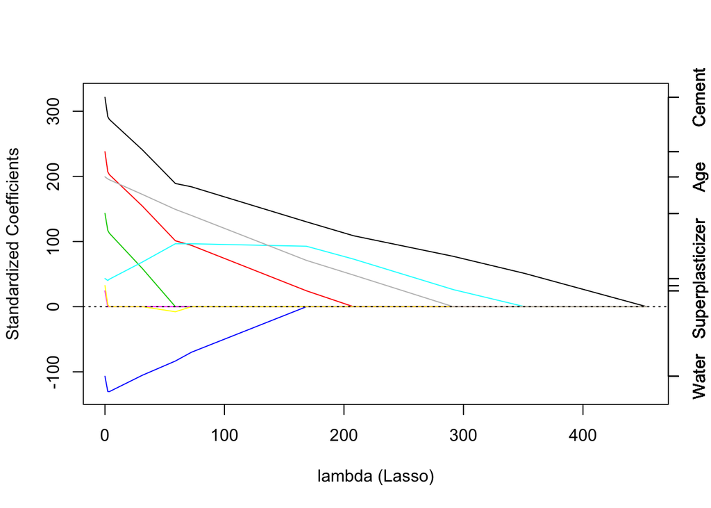

```r
set.seed(3523)
data(concrete)
inTrain = createDataPartition(concrete$CompressiveStrength, p = 3/4)[[1]]
training = concrete[ inTrain,]
testing = concrete[-inTrain,]

set.seed(233)
modLasso <- train(CompressiveStrength~., data=training, method="lasso")
library(elasticnet)
plot.enet(modLasso$finalModel, xvar = "penalty", use.color = TRUE)
```

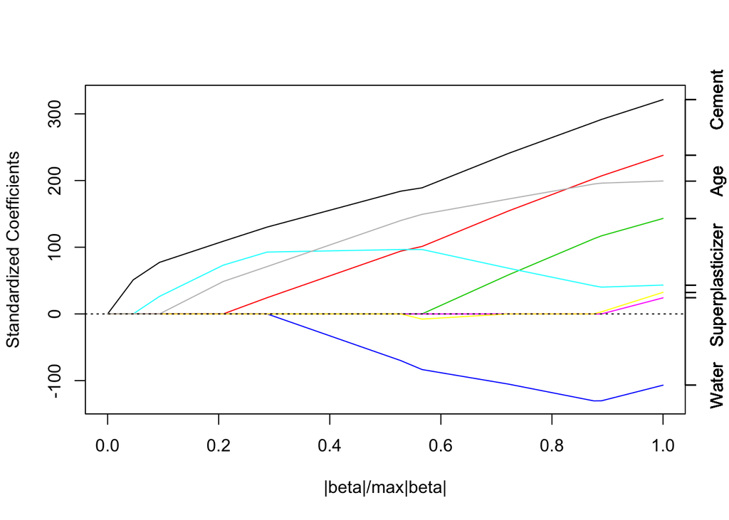

```r
plot.enet(modLasso$finalModel, use.color = TRUE)
```

## 4)

Load the data on the number of visitors to the instructors blog from here:

https://d396qusza40orc.cloudfront.net/predmachlearn/gaData.csv

Fit a model using the bats() function in the forecast package to the training time series. Then forecast this model for the remaining time points. For how many of the testing points is the true value within the 95% prediction interval bounds?

```r
library(lubridate)
library(forecast)
dat = read.csv("../data/gaData.csv")
training = dat[year(dat$date) < 2012,]
testing = dat[(year(dat$date)) > 2011,]
tstrain = ts(training$visitsTumblr)

modFit <- bats(tstrain)

# Forecast
# ?forecast
modForecast <- forecast(modFit, level = 95, h = dim(testing)[1])
#modForecast

# extract the 95% prediction boundary
sum(modForecast$lower < testing$visitsTumblr & testing$visitsTumblr < modForecast$upper)/length(testing$visitsTumblr)
```

```
[1] 0.9617021
```

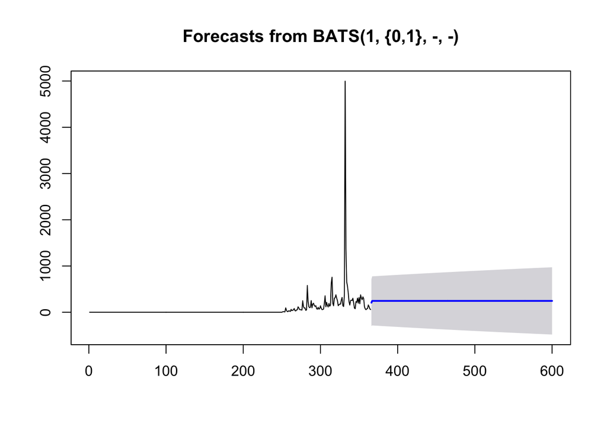

```r
plot(modForecast)
```

## 5)

Load the concrete data.

Set the seed to 325 and fit a support vector machine using the e1071 package to predict Compressive Strength using the default settings. Predict on the testing set. What is the RMSE?

```r
data(concrete)
inTrain = createDataPartition(concrete$CompressiveStrength, p = 3/4)[[1]]
training = concrete[ inTrain,]
testing = concrete[-inTrain,]

set.seed(325)
modSVM <- svm(CompressiveStrength~., data = training)
predictSVM <- predict(modSVM, testing)
accuracy(predictSVM, testing$CompressiveStrength)
```

```
                ME     RMSE      MAE       MPE     MAPE
Test set 0.2463267 6.989871 5.106734 -6.104579 18.32801
```

```r
# Root Mean Squared Error
error = predictSVM- testing$CompressiveStrength
sqrt(mean(error^2))
```

```
[1] 6.989871
```